# Preprocessing Highlight from various sources, with focus in ASIA

Hua

# Aim: Pre-processing highlights from various sources, with a focus on Asia

## Sources:

- Malaria Atlas in R
- RGBIF
- GBIF Website
- VectorBase Website

## Family: Leucosphyrus complex & Dirus complex

- Anopheles leucosphyrus
- Anopheles latens
- Anopheles introlatus
- Anopheles balabacensis
- Anopheles baisasi
- Anopheles dirus
- Anopheles cracens
- Anopheles scanloni
- Anopheles baimaii
- Anopheles elegans

## Required libraries

```r
library(malariaAtlas)
library(dplyr)
library(RSQLite)
library(DBI)
library(sf)
library(rnaturalearth)
library(stringr)
library(rgbif)
library(readr)
```

# Part 1: Understanding the structure of each dataset and filtering important attributes.

# First source: Malaria Atlas in R

## Data extraction:

```r
library(malariaAtlas)

# Technically I should only extract the data from ASIA, but I was just trying to get as many data in the first place.
# Africa
vectors_africa <- getVecOcc(continent = "Africa")
```

```
## Loading ISO 19139 XML schemas...
```

```
## Loading ISO 19115 codelists...
```

[output not shown]

[output not shown]

[output not shown]

[output not shown]

```
## Confirming availability of Vector data for: Africa...
```

```
## Vector points are available for Africa.
```

```
## Attempting to download vector occurence data for Sudan, Benin, Sudan, Comoros, Kenya, South Africa, Tanzania (United Republic of), Democratic Republic of the Congo, Ethiopia, Cameroon, Guinea, Burkina Faso, Senegal, Uganda, Mozambique, Mali, Madagascar, Guinea-Bissau, Niger, The Gambia, Côte d'Iv…
```

[output not shown]

```
## Data downloaded for Sudan, Benin, Comoros, Kenya, South Africa, Tanzania (United Republic of), Democratic Republic of the Congo, Ethiopia, Cameroon, Guinea, Burkina Faso, Senegal, Uganda, Mozambique, Mali, Madagascar, Guinea-Bissau, Niger, The Gambia, Côte d'Ivoire, São Tomé and Príncipe, Nigeria…
```

```r
# Asia
vectors_asia <- getVecOcc(continent = "Asia")
```

[output not shown]

[output not shown]

[output not shown]

[output not shown]

```
## Confirming availability of Vector data for: Asia...
```

```
## Vector points are available for Asia.
```

```
## Attempting to download vector occurence data for Philippines, Viet Nam, Thailand, Malaysia, Myanmar, Lao People's Democratic Republic, Indonesia, Cambodia, India, China, Turkey, Sri Lanka, Pakistan, Timor-Leste, Azerbaijan, Iran, Saudi Arabia, Armenia, Korea, Republic of, Singapore, Nepal, Korea,…
```

[output not shown]

```
## Data downloaded for Philippines, Viet Nam, Thailand, Malaysia, Myanmar, Lao People's Democratic Republic, Indonesia, Cambodia, India, China, Turkey, Sri Lanka, Pakistan, Timor-Leste, Azerbaijan, Iran, Saudi Arabia, Armenia, Korea, Republic of, Singapore, Nepal, Korea, Democratic People's Republic…
```

```r
# Europe
vectors_europe <- getVecOcc(continent = "Europe")
```

[output not shown]

[output not shown]

[output not shown]

[output not shown]

```
## Confirming availability of Vector data for: Europe...
```

```
## Vector points are available for Europe.
```

```
## Attempting to download vector occurence data for Spain, France, United Kingdom, Netherlands, Italy, Greece, Romania, Belgium, Montenegro, Austria, Sweden, Albania, Russian Federation, Macedonia, the former Yugoslav Republic of, Switzerland, Hungary, Serbia, Bulgaria, Croatia, Bosnia and Herzegovi…
```

[output not shown]

```
## Data downloaded for Spain, France, United Kingdom, Netherlands, Italy, Greece, Romania, Belgium, Montenegro, Austria, Sweden, Albania, Russian Federation, Macedonia, the former Yugoslav Republic of, Switzerland, Hungary, Serbia, Bulgaria, Croatia, Bosnia and Herzegovina, Czech Republic, Germany, …
```

```r
# Americas
vectors_americas <- getVecOcc(continent = "Americas")
```

[output not shown]

[output not shown]

[output not shown]

[output not shown]

```
## Confirming availability of Vector data for: Americas...
```

```
## Vector points are available for Americas.
```

```
## Attempting to download vector occurence data for Costa Rica, Nicaragua, Brazil, Venezuela, French Guiana, Bolivia, Peru, Colombia, Guatemala, Suriname, Belize, Trinidad and Tobago, Cuba, Mexico, El Salvador, United States of America, Dominican Republic, Guyana, Grenada, Ecuador, Argentina, Haiti,…
```

[output not shown]

```
## Data downloaded for Costa Rica, Nicaragua, Brazil, Venezuela, French Guiana, Bolivia, Peru, Colombia, Guatemala, Suriname, Belize, Trinidad and Tobago, Cuba, Mexico, El Salvador, United States of America, Dominican Republic, Guyana, Grenada, Ecuador, Argentina, Haiti, Honduras, Paraguay, Panama,
```

```r
# Oceania
vectors_oceania <- getVecOcc(continent = "Oceania")
```

[output not shown]

[output not shown]

[output not shown]

[output not shown]

```
## Confirming availability of Vector data for: Oceania...
```

```
## Vector points are available for Oceania.
```

```
## Attempting to download vector occurence data for Papua New Guinea, Vanuatu, Solomon Islands, Australia ...
```

[output not shown]

```
## Data downloaded for Papua New Guinea, Vanuatu, Solomon Islands, Australia,
```

```r
data_1 <- rbind(vectors_africa, vectors_asia, vectors_europe, vectors_americas, vectors_oceania) #28770
```

## Data filter & Selection

```r
# select important attributes
data_1.1<-dplyr::select (data_1, site_id, species_plain, species, country,continent_id, latitude, longitude,time_start,sample_method1,geometry) # We could include unique_id (id) to identify individual sample with similar attributes



# To check the available species in the data
unique_species <- unique(data_1.1$species_plain)
print(unique_species)
```

```
##  [1] "Anopheles gambiae "           "Anopheles arabiensis"
##  [3] "Anopheles coluzzii"           "Anopheles gambiae"
##  [5] "Anopheles funestus"           "Anopheles merus"
##  [7] "Anopheles melas"              "Anopheles moucheti"
##  [9] "Anopheles nili"               "Anopheles sergentii"
## [11] "Anopheles culicifacies"       "Anopheles labranchiae"
## [13] "Anopheles flavirostris"       "Anopheles maculatus"
## [15] "Anopheles minimus"            "Anopheles dirus"
## [17] "Anopheles barbirostris"       "Anopheles aconitus"
## [19] "Anopheles sinensis"           "Anopheles annularis"
## [21] "Anopheles stephensi"          "Anopheles subpictus"
## [23] "Anopheles koliensis"          "Anopheles punctulatus"
## [25] "Anopheles farauti"            "Anopheles sundaicus"
## [27] "Anopheles balabacensis"       "Anopheles lesteri"
## [29] "Anopheles sacharovi"          "Anopheles superpictus"
## [31] "Anopheles fluviatilis"        "Anopheles leucosphyrus"
## [33] "Anopheles messeae"            "Anopheles atroparvus"
## [35] "Anopheles albimanus"          "Anopheles pseudopunctipennis"
## [37] "Anopheles darlingi"           "Anopheles nuneztovari"
## [39] "Anopheles albitarsis"         "Anopheles aquasalis"
## [41] "Anopheles marajoara"          "Anopheles quadrimaculatus"
## [43] "Anopheles freeborni"
```

```r
# Function to check the number of occurences in each species
count_words <- function(data, column_name, words) {

  # Count occurrences for each word
  counts <- sapply(words, function(word) {
    sum(grepl(word, data[[column_name]], ignore.case = TRUE))
  })

  # Return a named vector of counts
  names(counts) <- words
  return(counts)
}

# Species to check
words_to_check <- c("Anopheles leucosphyrus", "Anopheles latens", "Anopheles introlatus", "Anopheles balabacensis", "Anopheles baisasi", "Anopheles dirus","Anopheles cracens", "Anopheles scanloni", "Anopheles baimaii", "Anopheles elegans")

word_counts_1 <- count_words(data_1.1, "species_plain", words_to_check)
print(word_counts_1)
```

```
## Anopheles leucosphyrus       Anopheles latens   Anopheles introlatus
##                     12                      0                      0
## Anopheles balabacensis      Anopheles baisasi        Anopheles dirus
##                     49                      0                    797
##      Anopheles cracens     Anopheles scanloni      Anopheles baimaii
##                      0                      0                      0
##      Anopheles elegans
##                      0
```

```r
# Filter selected species
data_1.2<-data_1.1 %>%
  filter(species_plain %in% c("Anopheles leucosphyrus", "Anopheles balabacensis", "Anopheles dirus"))

head(data_1.2)
```

```
## Simple feature collection with 6 features and 9 fields
## Geometry type: POINT
## Dimension:     XY
## Bounding box:  xmin: 99.1833 ymin: 14.2833 xmax: 99.1833 ymax: 14.2833
## Geodetic CRS:  WGS 84
##      site_id   species_plain                         species  country
## 1 1000000025 Anopheles dirus Anopheles dirus species complex Thailand
## 2 1000000025 Anopheles dirus Anopheles dirus species complex Thailand
## 3 1000000025 Anopheles dirus Anopheles dirus species complex Thailand
## 4 1000000025 Anopheles dirus Anopheles dirus species complex Thailand
## 5 1000000025 Anopheles dirus Anopheles dirus species complex Thailand
## 6 1000000025 Anopheles dirus Anopheles dirus species complex Thailand
##   continent_id latitude longitude time_start    sample_method1
## 1         Asia  14.2833   99.1833 2001-04-01 larval collection
## 2         Asia  14.2833   99.1833 2000-03-01 larval collection
## 3         Asia  14.2833   99.1833 2000-12-01 larval collection
## 4         Asia  14.2833   99.1833 2000-01-01 larval collection
## 5         Asia  14.2833   99.1833 2000-02-01 larval collection
## 6         Asia  14.2833   99.1833 2000-04-01 larval collection
##                  geometry
## 1 POINT (99.1833 14.2833)
## 2 POINT (99.1833 14.2833)
## 3 POINT (99.1833 14.2833)
## 4 POINT (99.1833 14.2833)
## 5 POINT (99.1833 14.2833)
## 6 POINT (99.1833 14.2833)
```

```r
nrow(data_1.2) #858
```

```
## [1] 858
```

## Data Modification & Standardisation highlights:

1. Added source and complex
2. Round latitude, longitude, and geometry for standardisation purpose
3. Investigate rows with NAs.

```r
# 1) Added sources & complex for back tracking purpose
data_1.2$complex <- ifelse(
    grepl("leucosphyrus|introlatus|balabacensis", data_1.2$species_plain, ignore.case = TRUE),
    "leucosphyrus",
    ifelse(
        grepl("dirus|cracens|scanloni|baimaii|elegans", data_1.2$species_plain, ignore.case = TRUE),
        "dirus",
        NA
    )
)
data_1.2$sources<- "MalariaAtlasinR"



# 2) Round latitude, longitude, and geometry to 2 decimal places
round_coordinates <- function(geom) {
    coords <- st_coordinates(geom)
    coords <- round(coords, 2)
    st_point(coords)
}

data_1_clean <- data_1.2 %>%
  mutate(
    latitude = round(latitude, 2),
    longitude = round(longitude, 2),
    geometry = st_sfc(lapply(geometry, round_coordinates), crs = st_crs(data_1.2))
  )

# 3) To investigate any rows with NAs
rows_with_na_1 <- data_1_clean[apply(data_1_clean, 1, function(x) any(is.na(x))), ]
#There are 150 rows with NAs, all in time_start. However, we will keep them for data integrity. This is because all data from VectorBase do not contain time or date, so we will not remove NAs from other sources either.

# To visualise clean data
head(data_1_clean)
```

```
## Simple feature collection with 6 features and 11 fields
## Geometry type: POINT
## Dimension:     XY
## Bounding box:  xmin: 99.18 ymin: 14.28 xmax: 99.18 ymax: 14.28
## Geodetic CRS:  WGS 84
##      site_id   species_plain                         species  country
## 1 1000000025 Anopheles dirus Anopheles dirus species complex Thailand
## 2 1000000025 Anopheles dirus Anopheles dirus species complex Thailand
## 3 1000000025 Anopheles dirus Anopheles dirus species complex Thailand
## 4 1000000025 Anopheles dirus Anopheles dirus species complex Thailand
## 5 1000000025 Anopheles dirus Anopheles dirus species complex Thailand
## 6 1000000025 Anopheles dirus Anopheles dirus species complex Thailand
##   continent_id latitude longitude time_start    sample_method1
## 1         Asia    14.28     99.18 2001-04-01 larval collection
## 2         Asia    14.28     99.18 2000-03-01 larval collection
## 3         Asia    14.28     99.18 2000-12-01 larval collection
## 4         Asia    14.28     99.18 2000-01-01 larval collection
## 5         Asia    14.28     99.18 2000-02-01 larval collection
## 6         Asia    14.28     99.18 2000-04-01 larval collection
##              geometry complex         sources
## 1 POINT (99.18 14.28)   dirus MalariaAtlasinR
## 2 POINT (99.18 14.28)   dirus MalariaAtlasinR
## 3 POINT (99.18 14.28)   dirus MalariaAtlasinR
## 4 POINT (99.18 14.28)   dirus MalariaAtlasinR
## 5 POINT (99.18 14.28)   dirus MalariaAtlasinR
## 6 POINT (99.18 14.28)   dirus MalariaAtlasinR
```

## Map Visualisation

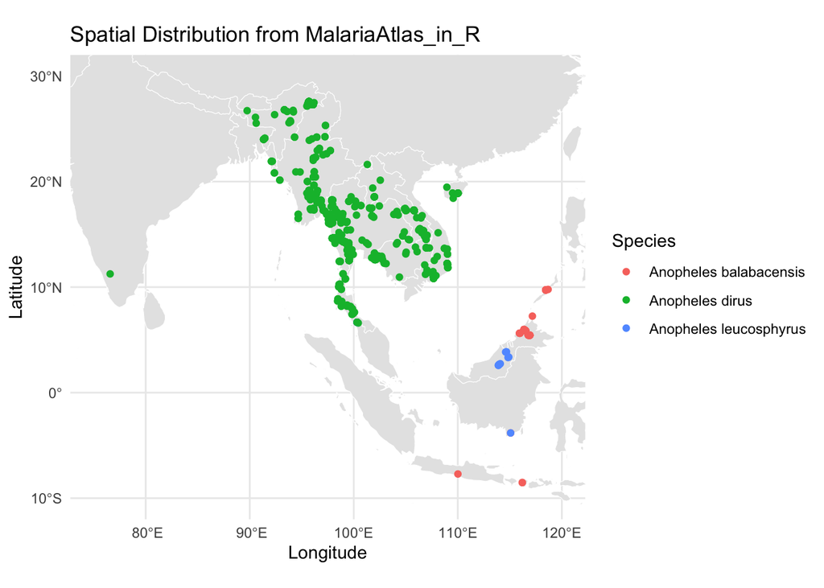

## Summary:

- Only 3 species available

- 858 data recorded

- 150 rows contain NAs - all in time_start. We could view the rows with NAs by print(rows_with_na_1)

# Second source: RGBIF

## Data extraction:

- We will not include Anopheles latens (do not have latitude & longitude) and Anopheles Baisasi (no record found)

```r
# Search for Anopheles leucosphyrus complex occurrences in RGBIF
leucosphyrus_data <- occ_search(
    scientificName = "Anopheles leucosphyrus"

)

latens_data <- occ_search(
    scientificName = "Anopheles latens"

)

introlatus_data <- occ_search(
    scientificName = "Anopheles introlatus"

)

balabacensis_data <- occ_search(
    scientificName = "Anopheles balabacensis"

)

baisasi_data <- occ_search(
    scientificName = "Anopheles baisasi"

)


# Search for Anopheles dirus complex occurrences in RGBIF
dirus_data <- occ_search(
    scientificName = "Anopheles dirus"
)

cracens_data <- occ_search(
    scientificName = "Anopheles cracens"

)

scanloni_data <- occ_search(
    scientificName = "Anopheles scanloni"

)

baimaii_data <- occ_search(
    scientificName = "Anopheles baimaii"

)

elegans_data <- occ_search(
    scientificName = "Anopheles elegans"

)

# Leucosphyrus complex
leucosphyrus_data_3a<-leucosphyrus_data$data
latens_data_3a<-latens_data$data #Columns `decimalLatitude`, `decimalLongitude`, and `geodeticDatum` don't exist.
introlatus_data_3a<-introlatus_data$data
balabacensis_data_3a<-balabacensis_data$data
baisasi_data_3a<-baisasi_data$data # no record found

# Dirus complex
dirus_data_3a<-dirus_data$data
cracens_data_3a<-cracens_data$data
scanloni_data_3a<-scanloni_data$data
baimaii_data_3a<-baimaii_data$data
elegans_data_3a<-elegans_data$data
```

## Data filter & Selection

```r
# Function to extract specific attributes
extract_and_clean_2 <- function(data) {
    extracted_data_3 <- dplyr::select(data,scientificName, acceptedScientificName, occurrenceStatus, kingdom, phylum, order, family, species, country, continent, decimalLatitude, decimalLongitude, eventDate)

    return(extracted_data_3)
}

leucosphyrus_data_3a<-extract_and_clean_2(leucosphyrus_data_3a)
introlatus_data_3a<-extract_and_clean_2(introlatus_data_3a)
balabacensis_data_3a<-extract_and_clean_2(balabacensis_data_3a)
dirus_data_3a<-extract_and_clean_2(dirus_data_3a)
cracens_data_3a<-extract_and_clean_2(cracens_data_3a)
scanloni_data_3a<-extract_and_clean_2(scanloni_data_3a)
baimaii_data_3a<-extract_and_clean_2(baimaii_data_3a)
elegans_data_3a<-extract_and_clean_2(elegans_data_3a)

data_3a<-rbind(leucosphyrus_data_3a,introlatus_data_3a, balabacensis_data_3a, dirus_data_3a, cracens_data_3a,scanloni_data_3a,baimaii_data_3a, elegans_data_3a )

data_3a
```

```
## # A tibble: 1,603 × 13
##    scientificName   acceptedScientificName occurrenceStatus kingdom phylum order
##    <chr>            <chr>                  <chr>            <chr>   <chr>  <chr>
##  1 Anopheles leuco… Anopheles leucosphyru… PRESENT          Animal… Arthr… Dipt…
##  2 Anopheles leuco… Anopheles leucosphyru… PRESENT          Animal… Arthr… Dipt…
##  3 Anopheles leuco… Anopheles leucosphyru… PRESENT          Animal… Arthr… Dipt…
##  4 Anopheles leuco… Anopheles leucosphyru… PRESENT          Animal… Arthr… Dipt…
##  5 Anopheles leuco… Anopheles leucosphyru… PRESENT          Animal… Arthr… Dipt…
##  6 Anopheles leuco… Anopheles leucosphyru… PRESENT          Animal… Arthr… Dipt…
##  7 Anopheles leuco… Anopheles leucosphyru… PRESENT          Animal… Arthr… Dipt…
##  8 Anopheles leuco… Anopheles leucosphyru… PRESENT          Animal… Arthr… Dipt…
##  9 Anopheles leuco… Anopheles leucosphyru… PRESENT          Animal… Arthr… Dipt…
## 10 Anopheles leuco… Anopheles leucosphyru… PRESENT          Animal… Arthr… Dipt…
## # ℹ 1,593 more rows
## # ℹ 7 more variables: family <chr>, species <chr>, country <chr>,
## #   continent <chr>, decimalLatitude <dbl>, decimalLongitude <dbl>,
## #   eventDate <chr>
```

```r
nrow(data_3a) #1603
```

```
## [1] 1603
```

## Data Modification & Standardisation highlights:

1. Added source and complex
2. Added continent for Indonesia and China
3. Rounded latitude, and longitude for standardisation purpose
4. Removed rows with missing latitude/ longitude (main priority)
5. Date Standardisation
6. Investigate rows with NAs.

```r
# 1) Added sources & complex for back tracking purpose
data_3a$sources<- "Rgbif"

data_3a$complex <- ifelse(
    grepl("leucosphyrus|introlatus|balabacensis", data_3a$species, ignore.case = TRUE),
    "leucosphyrus",
    ifelse(
        grepl("dirus|cracens|scanloni|baimaii|elegans", data_3a$species, ignore.case = TRUE),
        "dirus",
        NA
    )
)

# 2) Added continent for Indonesia and China as they were NAs in the first place.
data_3a$continent[(data_3a$country == "Indonesia" | data_3a$country == "China") & is.na(data_3a$continent)] <- "ASIA"

# 3) Rounded latitude, and longitude to 2 decimal places.
data_3a <- data_3a %>%
    mutate(
        decimalLatitude = round(decimalLatitude, 2),
        decimalLongitude = round(decimalLongitude, 2)
    )

# 4) remove rows with missing latitude/ longitude
data_3a.1<- data_3a %>%
    filter(!is.na(decimalLatitude) | !is.na(decimalLongitude))
nrow(data_3a.1) # 1216 rows remaining
```

```
## [1] 1216
```

```r
# 5) Date standadisation (There are three different categories: YYYY/MM/DD, YYYY/MM/DD / YYYY/MM/DD, YYYY/MM, YYYY)
data_3a.2 <- data_3a.1 %>%
    mutate(
        time_start = case_when(
            # Handle YYYY-MM format (add "01" as the day) - taking reference from MalariaAtlasinR as all of its' date start from 01.
            str_detect(eventDate, "^\\d{4}-\\d{2}$") ~ paste0(eventDate, "-01"),

            # Handle YYYY-MM-DD format (keep as is)
            str_detect(eventDate, "^\\d{4}-\\d{2}-\\d{2}$") ~ eventDate,

            # Handle date ranges (extract the start date)
            str_detect(eventDate, "/") ~ str_extract(eventDate, "^[^/]+"),

            # Handle any other cases (set to NA)
            TRUE ~ NA
        )
    )  # Again. We do not remove rows with NAs in date to ensure the intergrity. (Vectorbase)
data_3a.3 <- data_3a.2 %>% dplyr::select(-eventDate) # Because we have timestart.

# 6) To investigate any rows with NAs
rows_with_na_3a <- data_3a.3[apply(data_3a.3, 1, function(x) any(is.na(x))), ] # 58 rows in NAs. All in time_start.



# Reused the function to check the number of occurences in each species
word_counts_3a <- count_words(data_3a.3, "species", words_to_check)
print(word_counts_3a)
```

```
## Anopheles leucosphyrus       Anopheles latens   Anopheles introlatus
##                     46                      0                      5
## Anopheles balabacensis      Anopheles baisasi        Anopheles dirus
##                    286                      0                    441
##      Anopheles cracens     Anopheles scanloni      Anopheles baimaii
##                      2                     12                    423
##      Anopheles elegans
##                      1
```

```r
#Convert into sf data.
data_3a_clean <- st_as_sf(data_3a.3, coords = c("decimalLongitude", "decimalLatitude"), crs = 4326)

# To visualise cleaned data
data_3a_clean # 1216 data
```

```
## Simple feature collection with 1216 features and 13 fields
## Geometry type: POINT
## Dimension:     XY
## Bounding box:  xmin: 75.9 ymin: -5.31 xmax: 122.04 ymax: 19.03
## Geodetic CRS:  WGS 84
## # A tibble: 1,216 × 14
##    scientificName   acceptedScientificName occurrenceStatus kingdom phylum order
##  * <chr>            <chr>                  <chr>            <chr>   <chr>  <chr>
##  1 Anopheles leuco… Anopheles leucosphyru… PRESENT          Animal… Arthr… Dipt…
##  2 Anopheles leuco… Anopheles leucosphyru… PRESENT          Animal… Arthr… Dipt…
##  3 Anopheles leuco… Anopheles leucosphyru… PRESENT          Animal… Arthr… Dipt…
##  4 Anopheles leuco… Anopheles leucosphyru… PRESENT          Animal… Arthr… Dipt…
##  5 Anopheles leuco… Anopheles leucosphyru… PRESENT          Animal… Arthr… Dipt…
##  6 Anopheles leuco… Anopheles leucosphyru… PRESENT          Animal… Arthr… Dipt…
##  7 Anopheles leuco… Anopheles leucosphyru… PRESENT          Animal… Arthr… Dipt…
##  8 Anopheles leuco… Anopheles leucosphyru… PRESENT          Animal… Arthr… Dipt…
##  9 Anopheles leuco… Anopheles leucosphyru… PRESENT          Animal… Arthr… Dipt…
## 10 Anopheles leuco… Anopheles leucosphyru… PRESENT          Animal… Arthr… Dipt…
## # ℹ 1,206 more rows
## # ℹ 8 more variables: family <chr>, species <chr>, country <chr>,
## #   continent <chr>, sources <chr>, complex <chr>, time_start <chr>,
## #   geometry <POINT [°]>
```

## Map Visualisation

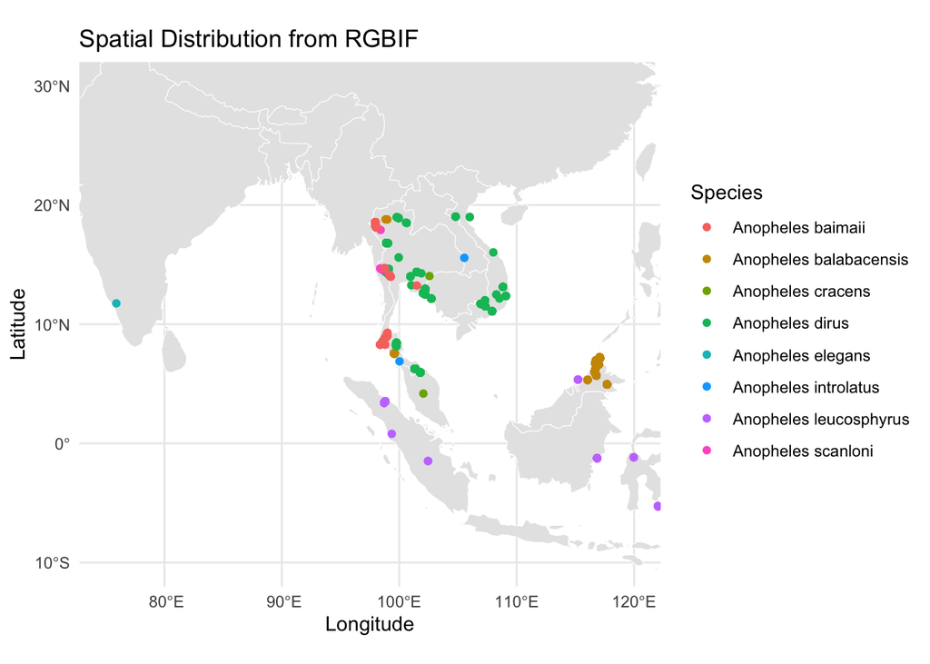

```r
world <- ne_countries(scale = "medium", returnclass = "sf")

ggplot() +
    geom_sf(data = world, fill = "gray90", color = "white") + # Base map
    geom_sf(data = data_3a_clean, aes(color = species)) +      # Overlay points
    theme_minimal() +
    labs(color = "Species") + xlim(75, 120) + ylim(-10, 30) + labs(title = "Spatial Distribution from RGBIF",x = "Longitude", y = "Latitude")
```

## Summary:

- Anopheles latens do not have latitude& longitude

- Anopheles baisasi doesn’t exists

- Only 8 species available

- Indonesia & China contained Na for continent

- 1216 data recorded

- Date standardised to the same format

- 58 rows contain NAs - all in time_start. We could view the rows with NAs by print(rows_with_na_3a)

# Third source: GBIF Website

Data extraction:

```r
# Please download the required file from the GBIF website
data_3b <- read.delim("gbif_extracted_dataset.csv", stringsAsFactors = FALSE) # may not be up to date

# View the first few rows
summary(data_3b)
```

```
##      gbifID           datasetKey        occurrenceID         kingdom
##  Min.   :1.772e+08   Length:1224        Length:1224        Length:1224
##  1st Qu.:2.261e+08   Class :character   Class :character   Class :character
##  Median :3.349e+09   Mode  :character   Mode  :character   Mode  :character
##  Mean   :2.734e+09
##  3rd Qu.:4.540e+09
##  Max.   :4.540e+09
##
##     phylum             class              order              family
##  Length:1224        Length:1224        Length:1224        Length:1224
##  Class :character   Class :character   Class :character   Class :character
##  Mode  :character   Mode  :character   Mode  :character   Mode  :character
##
##
##
##
##     genus             species          infraspecificEpithet  taxonRank
##  Length:1224        Length:1224        Mode:logical         Length:1224
##  Class :character   Class :character   NA's:1224            Class :character
##  Mode  :character   Mode  :character                        Mode  :character
##
##
##
##
##  scientificName     verbatimScientificName verbatimScientificNameAuthorship
##  Length:1224        Length:1224            Length:1224
##  Class :character   Class :character       Class :character
##  Mode  :character   Mode  :character       Mode  :character
##
##
##
##
##  countryCode          locality         stateProvince      occurrenceStatus
##  Length:1224        Length:1224        Length:1224        Length:1224
##  Class :character   Class :character   Class :character   Class :character
##  Mode  :character   Mode  :character   Mode  :character   Mode  :character
##
##
##
##
```

[output cut: 49 more lines]

```
##  Length:1224        Length:1224        Length:1224        Mode:logical
##  Class :character   Class :character   Class :character   NA's:1224
##  Mode  :character   Mode  :character   Mode  :character
##
##
##
##
##  establishmentMeans lastInterpreted     mediaType            issue
##  Mode:logical       Length:1224        Length:1224        Length:1224
##  NA's:1224          Class :character   Class :character   Class :character
##                     Mode  :character   Mode  :character   Mode  :character
##
##
##
##
```

```r
nrow(data_3b) #1224
```

```
## [1] 1224
```

```r
colnames(data_3b)
```

```
##  [1] "gbifID"                           "datasetKey"
##  [3] "occurrenceID"                     "kingdom"
##  [5] "phylum"                           "class"
##  [7] "order"                            "family"
##  [9] "genus"                            "species"
## [11] "infraspecificEpithet"             "taxonRank"
## [13] "scientificName"                   "verbatimScientificName"
## [15] "verbatimScientificNameAuthorship" "countryCode"
## [17] "locality"                         "stateProvince"
## [19] "occurrenceStatus"                 "individualCount"
## [21] "publishingOrgKey"                 "decimalLatitude"
## [23] "decimalLongitude"                 "coordinateUncertaintyInMeters"
## [25] "coordinatePrecision"              "elevation"
## [27] "elevationAccuracy"                "depth"
## [29] "depthAccuracy"                    "eventDate"
## [31] "day"                              "month"
## [33] "year"                             "taxonKey"
## [35] "speciesKey"                       "basisOfRecord"
## [37] "institutionCode"                  "collectionCode"
## [39] "catalogNumber"                    "recordNumber"
## [41] "identifiedBy"                     "dateIdentified"
## [43] "license"                          "rightsHolder"
## [45] "recordedBy"                       "typeStatus"
## [47] "establishmentMeans"               "lastInterpreted"
## [49] "mediaType"                        "issue"
```

## Data filter & Selection

```r
# Select important attributes
data_3b.1<-  dplyr::select (data_3b,scientificName,species,occurrenceStatus, kingdom,phylum,order, family,species,countryCode,decimalLatitude,decimalLongitude, eventDate)
```

## Data Modification & Stadardisation

1. Added source, and complex
2. Added continent attribute (did not have continent)
3. Transformed country code into full name
4. Removed rows with NAs in latitude and longitude (main priority)
5. Date Standardisation
6. Round latitude and longitude into 2 decimal places

```r
# 1 & 2) Added sources, complex and continent
data_3b.1$sources<-"Gbif"
data_3b.1$continent<-"ASIA"

data_3b.1$complex <- ifelse(
    grepl("leucosphyrus|introlatus|balabacensis", data_3b.1$species, ignore.case = TRUE),
    "leucosphyrus",
    ifelse(
        grepl("dirus|cracens|scanloni|baimaii|elegans", data_3b.1$species, ignore.case = TRUE),
        "dirus",
        NA
    )
)

# 3) Transform country code
data_3b.2 <- data_3b.1 %>%
    mutate(country = recode(countryCode,
                            "TH" = "Thailand",
                            "IN" = "India",
                            "ID" = "Indonesia",
                            "VN" = "Vietnam",
                            "KH" = "Cambodia",
                            "MY" = "Malaysia"
    ),continent = "ASIA"
    ) %>%
    dplyr::select(-countryCode)  # Remove the old column

# 4) Remove rows with missing latitude & longitude
data_3b.3<- data_3b.2 %>%
    filter(!is.na(decimalLatitude) | !is.na(decimalLongitude))  # 1224 - did not remove any rows

# 5) Similar date standardisation
data_3b.4 <- data_3b.3 %>%
    mutate(
        time_start = case_when(
            # Handle YYYY-MM format (add "01" as the day)
            str_detect(eventDate, "^\\d{4}-\\d{2}$") ~ paste0(eventDate, "-01"),

            # Handle YYYY-MM-DD format (keep as is)
            str_detect(eventDate, "^\\d{4}-\\d{2}-\\d{2}$") ~ eventDate,

            # Handle date ranges (extract the start date)
            str_detect(eventDate, "/") ~ str_extract(eventDate, "^[^/]+"),

            # Handle any other cases (set to NA)
            TRUE ~ NA
        )
    )
data_3b.5 <- data_3b.4 %>% dplyr::select(-eventDate) # Because we have time_start.

# 6) Round the latitude and longitude
data_3b.6 <- data_3b.5 %>%
    mutate(
        decimalLatitude = round(decimalLatitude, 2),
        decimalLongitude = round(decimalLongitude, 2)
    )

# 7) Investigate rows with NAs
rows_with_na_3b <- data_3b.6[apply(data_3b.6, 1, function(x) any(is.na(x))), ] # 66 rows in NAs - all in time_start.

# Convert into sf data
data_3b_clean <- st_as_sf(data_3b.6, coords = c("decimalLongitude", "decimalLatitude"), crs = 4326) #1224

# reuse the function to count the number of occurences in each species
word_counts_3b <- count_words(data_3b_clean, "species", words_to_check)
print(word_counts_3b)
```

```
## Anopheles leucosphyrus       Anopheles latens   Anopheles introlatus
##                     46                      0                      5
## Anopheles balabacensis      Anopheles baisasi        Anopheles dirus
##                    286                      0                    439
##      Anopheles cracens     Anopheles scanloni      Anopheles baimaii
##                      2                     12                    433
##      Anopheles elegans
##                      1
```

```r
#To read the clean data
data_3b_clean
```

```
## Simple feature collection with 1224 features and 12 fields
## Geometry type: POINT
## Dimension:     XY
## Bounding box:  xmin: 75.9 ymin: -5.31 xmax: 122.04 ymax: 19.03
## Geodetic CRS:  WGS 84
## First 10 features:
##                             scientificName           species occurrenceStatus
## 1  Anopheles baimaii Sallum & Peyton, 2005 Anopheles baimaii          PRESENT
## 2  Anopheles baimaii Sallum & Peyton, 2005 Anopheles baimaii          PRESENT
## 3  Anopheles baimaii Sallum & Peyton, 2005 Anopheles baimaii          PRESENT
## 4  Anopheles dirus Peyton & Harrison, 1979   Anopheles dirus          PRESENT
## 5  Anopheles dirus Peyton & Harrison, 1979   Anopheles dirus          PRESENT
## 6  Anopheles baimaii Sallum & Peyton, 2005 Anopheles baimaii          PRESENT
## 7  Anopheles baimaii Sallum & Peyton, 2005 Anopheles baimaii          PRESENT
## 8  Anopheles baimaii Sallum & Peyton, 2005 Anopheles baimaii          PRESENT
```

[output cut: 24 more lines]

## Map Visualisation

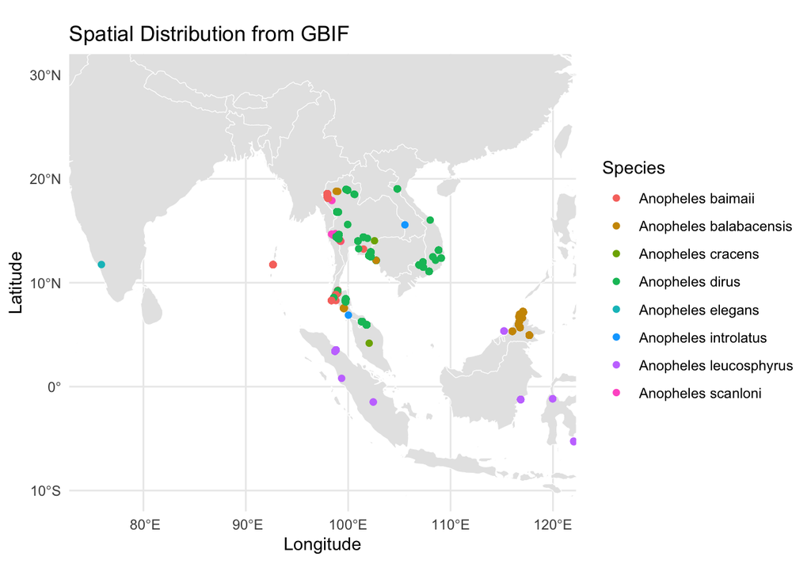

```r
world <- ne_countries(scale = "medium", returnclass = "sf")

ggplot() +
    geom_sf(data = world, fill = "gray90", color = "white") + # Base map
    geom_sf(data = data_3b_clean, aes(color = species)) +      # Overlay points
    theme_minimal() +
    labs(color = "Species") + xlim(75, 120) + ylim(-10, 30) + labs(title = "Spatial Distribution from GBIF",x = "Longitude", y = "Latitude")
```

## Summary:

- Only 8 species recorded
- Changed Country Code to full name.
- Added Continent attribute (Was not there originally)
- No missing geometry data
- Date standardised to the same format
- 1224 data recorded
- 66 rows contain NAs - all in time_start. We could view the rows with NAs by print(rows_with_na_3b)

# Fourth source: VectorBase Website

## Data extraction:

```r
# Please download the required dataset from VectorBase
collection_site <- read.table("Collection_sites.txt", header = TRUE, sep = "\t",fill = TRUE)
samples <- read.table("Samples.txt", header = TRUE, sep = "\t",fill = TRUE)
studies <- read.table("Studies.txt", header = TRUE, sep = "\t",fill = TRUE)


# connect relational database
site_samples <- merge(collection_site, samples, by = "Collection_site_ID", all = TRUE)
site_samples <- site_samples %>%
    dplyr::select(-Study_ID.x)
colnames(site_samples)[colnames(site_samples) == "Study_ID.y"] <- "Study_ID"
site_samples_studies<- merge(site_samples, studies, by = "Study_ID", all = TRUE)

head(site_samples_studies)
```

```
##        Study_ID               Collection_site_ID continent..GAZ_00000013.
## 1 2014-MAP-Asia    2014-MAP-Asia|2014-MAP-Asia_1                     Asia
## 2 2014-MAP-Asia    2014-MAP-Asia|2014-MAP-Asia_1                     Asia
## 3 2014-MAP-Asia 2014-MAP-Asia|2014-MAP-Asia_1009                     Asia
## 4 2014-MAP-Asia 2014-MAP-Asia|2014-MAP-Asia_1011                     Asia
## 5 2014-MAP-Asia 2014-MAP-Asia|2014-MAP-Asia_1011                     Asia
## 6 2014-MAP-Asia 2014-MAP-Asia|2014-MAP-Asia_1023                     Asia
##   Latitude..OBI_0001620. Longitude..OBI_0001621. country..OBI_0001627.
## 1                 12.444                  98.605               Myanmar
## 2                 12.444                  98.605               Myanmar
## 3                 15.167                  98.566              Thailand
## 4                 16.900                  98.650              Thailand
## 5                 16.900                  98.650              Thailand
## 6                  5.450                 116.783              Malaysia
##                 Sample_ID                      Collection_ID
```

[output cut: 20 more lines]

```r
nrow(site_samples_studies) #1293
```

```
## [1] 1293
```

```r
colnames(site_samples_studies)
```

```
##  [1] "Study_ID"                     "Collection_site_ID"
##  [3] "continent..GAZ_00000013."     "Latitude..OBI_0001620."
##  [5] "Longitude..OBI_0001621."      "country..OBI_0001627."
##  [7] "Sample_ID"                    "Collection_ID"
##  [9] "Sample.type..EUPATH_0000611." "species..OBI_0001909."
## [11] "protocol..OBI_0000272."       "Study.name..OBI_0001622."
```

## Data filter & Selection

```r
data_4_1 <- site_samples_studies %>%
    dplyr::select(Study.name..OBI_0001622.,species..OBI_0001909.,Sample.type..EUPATH_0000611.,protocol..OBI_0000272.,Latitude..OBI_0001620.,Longitude..OBI_0001621.,country..OBI_0001627.,continent..GAZ_00000013.)
```

## Data Modification & Standardisation

1. Added time_start and sources attribute
2. Rounded latitude and longitude into 2 decimal places
3. Investigate rows with NAs - All rows contain NAs in time_start.

```r
# 1) Added time_start and sources
data_4_1$time_start=NA
data_4_1$sources<-"Vectorbase"

# 2) Rounded latitude and longitude to 2 decimal places
data_4_2 <- data_4_1 %>%
    mutate(
        Latitude..OBI_0001620. = round(Latitude..OBI_0001620., 2),
        Longitude..OBI_0001621. = round(Longitude..OBI_0001621., 2)
    )

# 3) Investigate rows with NAs
rows_with_na_4 <- data_4_2[apply(data_4_2, 1, function(x) any(is.na(x))), ] # All rows contain NAs bcs of time_start

word_counts_4 <- count_words(data_4_2, "species..OBI_0001909.", words_to_check)
print(word_counts_4)
```

```
## Anopheles leucosphyrus       Anopheles latens   Anopheles introlatus
##                     12                      0                      0
## Anopheles balabacensis      Anopheles baisasi        Anopheles dirus
##                     93                      0                    841
##      Anopheles cracens     Anopheles scanloni      Anopheles baimaii
##                      0                      0                    347
##      Anopheles elegans
##                      0
```

```r
# Convert into sf data
data_4_clean <- st_as_sf(data_4_2, coords = c("Longitude..OBI_0001621.", "Latitude..OBI_0001620."), crs = 4326)
data_4_clean
```

```
## Simple feature collection with 1293 features and 8 fields
## Geometry type: POINT
## Dimension:     XY
## Bounding box:  xmin: 76.58 ymin: -8.55 xmax: 127.85 ymax: 27.58
## Geodetic CRS:  WGS 84
## First 10 features:
##                                                                Study.name..OBI_0001622.
## 1  Malaria Atlas Project: Global distribution of observed malaria vector species (Asia)
## 2  Malaria Atlas Project: Global distribution of observed malaria vector species (Asia)
## 3  Malaria Atlas Project: Global distribution of observed malaria vector species (Asia)
## 4  Malaria Atlas Project: Global distribution of observed malaria vector species (Asia)
## 5  Malaria Atlas Project: Global distribution of observed malaria vector species (Asia)
## 6  Malaria Atlas Project: Global distribution of observed malaria vector species (Asia)
## 7  Malaria Atlas Project: Global distribution of observed malaria vector species (Asia)
## 8  Malaria Atlas Project: Global distribution of observed malaria vector species (Asia)
```

[output cut: 35 more lines]

## Map Visualisation

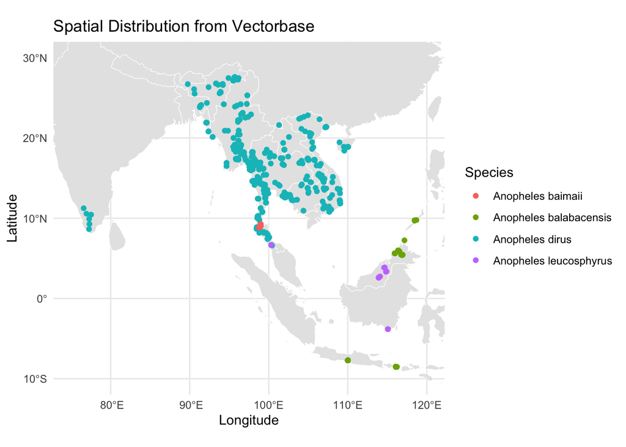

```r
world <- ne_countries(scale = "medium", returnclass = "sf")

ggplot() +
    geom_sf(data = world, fill = "gray90", color = "white") + # Base map
    geom_sf(data = data_4_clean, aes(color = species..OBI_0001909.)) +      # Overlay points
    theme_minimal() +
    labs(color = "Species") + xlim(75, 120) + ylim(-10, 30) + labs(title = "Spatial Distribution from Vectorbase",x = "Longitude", y = "Latitude")
```

Summary:

- Only 4 species available
- No missing geometry data
- Do not have time_start (Was not there originally)
- 1293 rows of data recorded

# Part 2 : Merging data with common attributes

## 1) Select common attributes from the cleaned data

```r
ref_data1 <- data_1_clean %>%
  dplyr::select(species_plain, country, continent_id, time_start, geometry,sources) %>%
  rename(species = species_plain, continent = continent_id) %>% # rename
  mutate(continent = toupper(continent),  # Convert continent to uppercase
         time_start = as.Date(time_start))

ref_data3a<-data_3a_clean%>%
  dplyr::select(species, geometry, country,continent, time_start, geometry,sources) %>%
  mutate (time_start = as.Date(time_start))

ref_data3b <-data_3b_clean%>%
  dplyr::select(species, country,continent,time_start, geometry,sources) %>%
  mutate (time_start = as.Date(time_start))

ref_data4<-data_4_clean%>%
  dplyr::select(species..OBI_0001909.,country..OBI_0001627.,continent..GAZ_00000013.,time_start,geometry,sources)%>% rename(species = species..OBI_0001909.,country=country..OBI_0001627.,continent=continent..GAZ_00000013.)%>%
    mutate(continent = toupper(continent))
```

## 2) Identify the non-matching rows between ref_data1 and ref_data3a - Data not in ref_data1 but in ref_data3a

```r
#Extract the data in ref_data3a but not in ref_data1, by using common attributes as reference
non_matching_rows_1_3a <- ref_data3a[!(ref_data3a$species %in% ref_data1$species  & ref_data3a$country %in% ref_data1$country& ref_data3a$continent %in% ref_data1$continent& ref_data3a$time_start %in% ref_data1$time_start& ref_data3a$geometry %in% ref_data1$geometry), ]  # 1210 rows found in ref_data3a but not in ref_data1

# reused the function to count the number of occurences in each species
word_counts_1_3a <- count_words(non_matching_rows_1_3a, "species", words_to_check)
print(word_counts_1_3a)
```

```
## Anopheles leucosphyrus       Anopheles latens   Anopheles introlatus
##                     46                      0                      5
## Anopheles balabacensis      Anopheles baisasi        Anopheles dirus
##                    286                      0                    435
##      Anopheles cracens     Anopheles scanloni      Anopheles baimaii
##                      2                     12                    423
##      Anopheles elegans
##                      1
```

```r
# combined the non_matching_rows with ref_data1, and reviewed the updated dataset
ref_data1_3a <- bind_rows(ref_data1, non_matching_rows_1_3a) # 2068
nrow(ref_data1_3a)
```

```
## [1] 2068
```

```r
# reused the function to count the number of occurences in each species
combined_1_3a <- count_words(ref_data1_3a, "species", words_to_check)
print(combined_1_3a)
```

```
## Anopheles leucosphyrus       Anopheles latens   Anopheles introlatus
##                     58                      0                      5
## Anopheles balabacensis      Anopheles baisasi        Anopheles dirus
##                    335                      0                   1232
##      Anopheles cracens     Anopheles scanloni      Anopheles baimaii
##                      2                     12                    423
##      Anopheles elegans
##                      1
```

```r
# now with the similar ideal, repeat the steps for ref_data3b, and ref_data4, but remember to replace with updated combined data
non_matching_rows_1_3a_3b <- ref_data3b[!(ref_data3b$species %in% ref_data1_3a$species  & ref_data3b$country %in% ref_data1_3a$country& ref_data3b$continent %in% ref_data1_3a$continent& ref_data3b$time_start %in% ref_data1_3a$time_start& ref_data3b$geometry %in% ref_data1_3a$geometry), ]

ref_data1_3a_3b<- bind_rows(ref_data1_3a,non_matching_rows_1_3a_3b) #2137

# reused the function to count the number of occurences in each species
checking_data_1_3a_3b <- count_words(ref_data1_3a_3b, "species", words_to_check)
print(checking_data_1_3a_3b)
```

```
## Anopheles leucosphyrus       Anopheles latens   Anopheles introlatus
##                     58                      0                      5
## Anopheles balabacensis      Anopheles baisasi        Anopheles dirus
##                    335                      0                   1291
##      Anopheles cracens     Anopheles scanloni      Anopheles baimaii
##                      2                     12                    433
##      Anopheles elegans
##                      1
```

```r
nrow(ref_data1_3a_3b)
```

```
## [1] 2137
```

```r
non_matching_rows_1_3a_3b_4 <- ref_data4[!(ref_data4$species %in% ref_data1_3a_3b$species  & ref_data4$country %in% ref_data1_3a_3b$country& ref_data4$continent %in% ref_data1_3a_3b$continent& ref_data4$geometry %in% ref_data1_3a_3b$geometry), ]

# We turned it to character to merge with data from VectorBase (NAs in date)
ref_data1_3a_3b$time_start = as.character(ref_data1_3a_3b$time_start)
ref_data1_3a_3b_4<- bind_rows(ref_data1_3a_3b,non_matching_rows_1_3a_3b_4) #2228

checking_data_1_3a_3b_4 <- count_words(ref_data1_3a_3b_4, "species", words_to_check)
# Print the count
print(checking_data_1_3a_3b_4)
```

```
## Anopheles leucosphyrus       Anopheles latens   Anopheles introlatus
##                     58                      0                      5
## Anopheles balabacensis      Anopheles baisasi        Anopheles dirus
##                    337                      0                   1380
##      Anopheles cracens     Anopheles scanloni      Anopheles baimaii
##                      2                     12                    433
##      Anopheles elegans
##                      1
```

```r
nrow(ref_data1_3a_3b_4)
```

```
## [1] 2228
```

```r
# To view the merge data
ref_data1_3a_3b_4
```

```
## Simple feature collection with 2228 features and 5 fields
## Geometry type: POINT
## Dimension:     XY
## Bounding box:  xmin: 75.9 ymin: -8.55 xmax: 127.85 ymax: 27.58
## Geodetic CRS:  WGS 84
## First 10 features:
##            species  country continent time_start         sources
## 1  Anopheles dirus Thailand      ASIA 2001-04-01 MalariaAtlasinR
## 2  Anopheles dirus Thailand      ASIA 2000-03-01 MalariaAtlasinR
## 3  Anopheles dirus Thailand      ASIA 2000-12-01 MalariaAtlasinR
## 4  Anopheles dirus Thailand      ASIA 2000-01-01 MalariaAtlasinR
## 5  Anopheles dirus Thailand      ASIA 2000-02-01 MalariaAtlasinR
## 6  Anopheles dirus Thailand      ASIA 2000-04-01 MalariaAtlasinR
## 7  Anopheles dirus Thailand      ASIA 2000-05-01 MalariaAtlasinR
## 8  Anopheles dirus Thailand      ASIA 2000-06-01 MalariaAtlasinR
## 9  Anopheles dirus Thailand      ASIA 2000-07-01 MalariaAtlasinR
## 10 Anopheles dirus Thailand      ASIA 2000-08-01 MalariaAtlasinR
##               geometry
## 1  POINT (99.18 14.28)
## 2  POINT (99.18 14.28)
## 3  POINT (99.18 14.28)
## 4  POINT (99.18 14.28)
## 5  POINT (99.18 14.28)
## 6  POINT (99.18 14.28)
## 7  POINT (99.18 14.28)
## 8  POINT (99.18 14.28)
## 9  POINT (99.18 14.28)
## 10 POINT (99.18 14.28)
```

```r
# To extract rows with NAs
non_spatial_data <- st_drop_geometry(ref_data1_3a_3b_4)
rows_with_na_complete_data <- non_spatial_data[apply(non_spatial_data, 1, function(x) any(is.na(x))), ]
nrow(rows_with_na_complete_data) #336 - All NAs are in time_start
```

```
## [1] 336
```

## 3) Map Visualisation

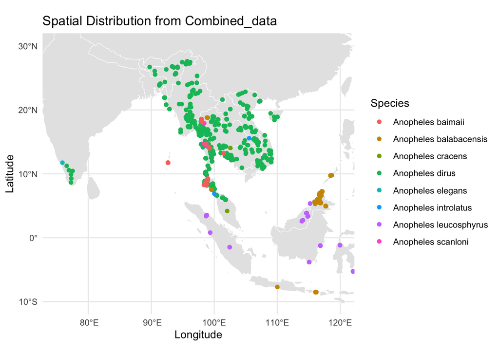

```r
world <- ne_countries(scale = "medium", returnclass = "sf")

ggplot() +
    geom_sf(data = world, fill = "gray90", color = "white") + # Base map
    geom_sf(data = ref_data1_3a_3b_4, aes(color = species)) +      # Overlay points
    theme_minimal() +
    labs(color = "Species") + xlim(75, 120) + ylim(-10, 30) + labs(title = "Spatial Distribution from Combined_data",x = "Longitude", y = "Latitude")
```

## Simple Visualisation

```r
## To visual number of species in the data set
species_count <- ref_data1_3a_3b_4 %>%
    group_by(species) %>%
    summarise(count = n()) %>%
    arrange(desc(count))
```

```
## although coordinates are longitude/latitude, st_union assumes that they are
## planar
```

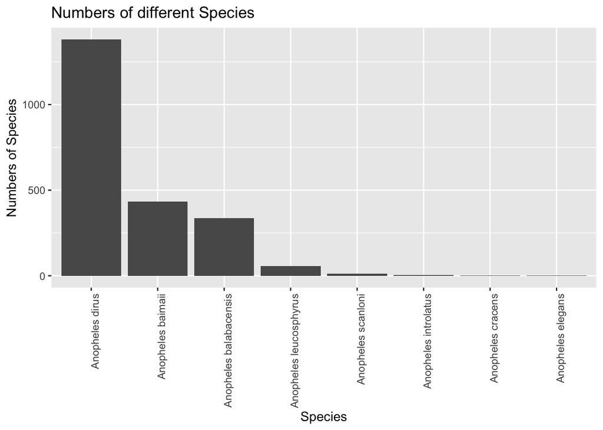

```r
# Create a histogram or bar plot of species counts
ggplot(species_count, aes(x = reorder(species, -count), y = count)) +
    geom_bar(stat = "identity") +
    labs(x = "Species", y = "Numbers of Species", title = "Numbers of different Species ") +
         theme(axis.text.x = element_text(angle = 90, hjust = 1))
```

```r
## To visual number of occurrences in each country
country_count <- ref_data1_3a_3b_4 %>%
    group_by(country) %>%
    summarise(count = n()) %>%
    arrange(desc(count))
```

```
## although coordinates are longitude/latitude, st_union assumes that they are
## planar
```

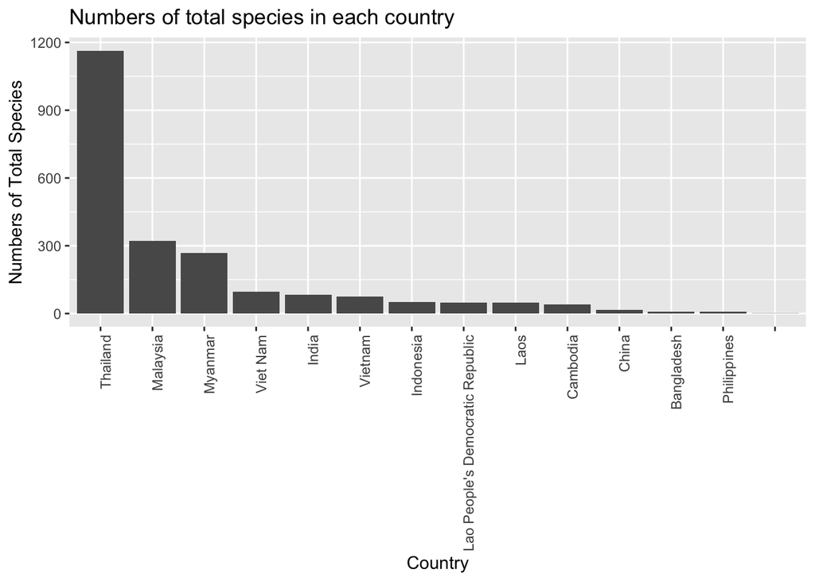

```r
# Create a histogram or bar plot of species counts
ggplot(country_count, aes(x = reorder(country, -count), y = count)) +
    geom_bar(stat = "identity") +
    labs(x = "Country", y = "Numbers of Total Species", title = "Numbers of total species in each country") +
         theme(axis.text.x = element_text(angle = 90, hjust = 1))
```

```r
## To plot sf object over raster data
raster_data <- getRaster(dataset_id = "Malaria__202206_Global_Pf_Incidence_Rate")
```

```
## Checking if the following Surface-Year combinations are available to download:
```

```
##
##     DATASET ID  YEAR
```

```
##   - Malaria__202206_Global_Pf_Incidence_Rate:  DEFAULT
```

```
## No encoding supplied: defaulting to UTF-8.
```

[output not shown]

```
## No encoding supplied: defaulting to UTF-8.
```

[output not shown]

```r
print(raster_data)
```

```
## class       : SpatRaster
## dimensions  : 2607, 6927, 1  (nrow, ncol, nlyr)
## resolution  : 0.04166667, 0.04166667  (x, y)
## extent      : -118.375, 170.25, -55.08333, 53.54167  (xmin, xmax, ymin, ymax)
## coord. ref. : lon/lat WGS 84 (EPSG:4326)
## source      : Malaria__202206_Global_Pf_Incidence_Rate_-55.0833358764648,-118.375,2000-01-01T00_00_00,53.5416679382324,170.250015258789,2020-01-01T00_00_00.tif
## name        : Number of newly diagnosed Plas~ion, on a given year 2000-2020
```

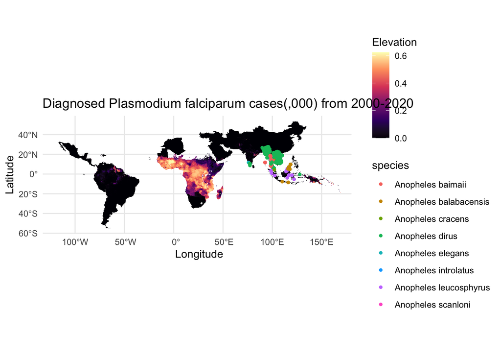

```r
raster_df <- as.data.frame(raster_data, xy = TRUE)

ggplot() +
        geom_raster(data = raster_df, aes(x = x, y = y, fill = `Number of newly diagnosed Plasmodium falciparum cases per 1,000 population, on a given year 2000-2020`)) +
        geom_sf(data = ref_data1_3a_3b_4, fill = NA, aes(color = species), size = 1) +
        scale_fill_viridis_c(option = "magma") +
        theme_minimal() +
        labs(title = "Diagnosed Plasmodium falciparum cases(,000) from 2000-2020", x = "Longitude", y = "Latitude", fill = "Elevation")
```